# R WIZARDRY FINAL PROJECT 2017

### Match Gene IDs to Protein Match from NCBI online database

```r
### Example start code
### Start with a single example to ensure proper results then expand into a for-loop
### Load in "rentrez" package for needed functions
library(rentrez)

### Use "entrez_search" function to create a list from the "gene" database search: db = "gene"
#### entrez_dbs() database = "gene" term = "NP_891985.1" (NCBI Gene Accession  ID)
### Use argument "retmax" to determine the maximum number of returned values
#### Returning a max value of 1: retmax = 1
### Sort by relevance so best match is at the top: sort = "relevance"

# Create a value called "gene_search" which is a list of 5 variables in this instance
### Term argument used is an NCBI Gene Accession ID
gene_search <- entrez_search(db="gene", term="NP_891985.1", retmax = 1, sort="relevance")

# Create a value called "geneid" equal to returned list from "gene_search" ids
geneid = gene_search$ids

# Create a list value called "res" to store "entrez_summary" info from the "gene" database specific to the "geneid" value from the "entrez_search" "ids" variable
res = entrez_summary(db = "gene", id = geneid)

# Create a value called "description" to store the protein description from "entrez_summary" info
description = res$description

# Confirm that Result is a Protein Description
description
```

```
## [1] "hemoglobin, alpha embryonic 1"
```

```r
### The end result is a protein description based on the provided NCBI Gene Accession ID from the created data frame stored as a value called "description"
```

### Code Background for rentrez package

```r
library(rentrez) ### Package Functions Breakdown
citation("rentrez")
```

```
##
##
##   David Winter (2016). rentrez: Entrez in R. R package version
##   1.0.4. https://CRAN.R-project.org/package=rentrez
##
## A BibTeX entry for LaTeX users is
##
##   @Manual{,
##     title = {rentrez: Entrez in R},
##     author = {David Winter},
##     year = {2016},
##     note = {R package version 1.0.4},
##     url = {https://CRAN.R-project.org/package=rentrez},
##   }
```

```r
### First use entrez_dbs() to find the list of available databases to search through:
entrez_dbs()
```

```
##  [1] "pubmed"          "protein"         "nuccore"
##  [4] "nucleotide"      "nucgss"          "nucest"
##  [7] "structure"       "sparcle"         "genome"
## [10] "annotinfo"       "assembly"        "bioproject"
## [13] "biosample"       "blastdbinfo"     "books"
## [16] "cdd"             "clinvar"         "clone"
## [19] "gap"             "gapplus"         "grasp"
## [22] "dbvar"           "gene"            "gds"
## [25] "geoprofiles"     "homologene"      "medgen"
## [28] "mesh"            "ncbisearch"      "nlmcatalog"
## [31] "omim"            "orgtrack"        "pmc"
## [34] "popset"          "probe"           "proteinclusters"
## [37] "pcassay"         "biosystems"      "pccompound"
## [40] "pcsubstance"     "pubmedhealth"    "seqannot"
## [43] "snp"             "sra"             "taxonomy"
## [46] "biocollections"  "unigene"         "gencoll"
## [49] "gtr"
```

```r
### Functions with names starting entrez_db_ gather more information about each entrez_dbs() databases:

entrez_db_summary("gene")   ### Brief description of what the database is
```

```
##  DbName: gene
##  MenuName: Gene
##  Description: Gene database
##  DbBuild: Build170412-0500m.1
##  Count: 27479290
##  LastUpdate: 2017/04/12 15:24
```

```r
entrez_db_searchable("gene") ### Set of search terms that can used with this database
```

```
## Searchable fields for database 'gene'
##   ALL     All terms from all searchable fields
##   UID     Unique number assigned to a gene record
##   FILT    Limits the records
##   TITL    gene or protein name
##   WORD    Free text associated with record
##   ORGN    scientific and common names of organism
##   MDAT    The last date on which the record was updated
##   CHR     Chromosome number or numbers; also 'mitochondrial', 'unknown' properties
##   MV      Chromosomal map location as displayed in MapViewer
##   GENE    Symbol or symbols of the gene
##   ECNO    EC number for enzyme or CAS registry number
##   MIM     MIM number from OMIM
##   DIS     Name(s) of diseases associated with this gene. When available, OMIM name will be used
##   ACCN    Nucleotide or protein accession(s) associated with this gene
##   UGEN    UniGene cluster number for this gene
##   PROP    Properties of Gene record
##   CDAT    The date on which this record first appeared
##   NCAC    nucleotide accessions of sequences
##   NUID    nucleotide uids of sequences
##   PACC    protein accessions
##   PUID    protein uids
##   PMID    PubMed ids of accessions linked to the record
##   TID     taxonomy id
##   GO      Gene Ontology
##   DOM     Domain Name
##   DDAT    The date on which the record was discontinued
##   CPOS    Chromosome base position
##   GFN     Gene full name
##   PFN     Protein full name
##   GL      Gene length
##   XC      Exon count
##   GRP     Relationships for this gene
##   PREF    Preferred symbol of the gene
##   AACC    Assembly accession
##   ASM     Assembly name
```

```r
entrez_db_links("gene") ### Set of databases that might contain linked records
```

```
## Databases with linked records for database 'gene'
##  [1] bioproject      biosystems      books           ccds
##  [5] cdd             clinvar         clinvar         dbvar
##  [9] gap             gene            gene            genome
## [13] geoprofiles     gtr             homologene      mapview
## [17] medgen          nuccore         nuccore         nuccore
## [21] nuccore         nucest          nucest          nucgss
## [25] nucleotide      omim            pcassay         pcassay
## [29] pcassay         pcassay         pcassay         pccompound
## [33] pcsubstance     pmc             pmc             probe
## [37] protein         protein         proteinclusters pubmed
## [41] pubmed          pubmed          pubmed          snp
## [45] snp             sparcle         structure       taxonomy
## [49] unigene         varview
```

### Step 8: Create for Loop to add protein info to gene IDs

### (description, scientific name of organism, nomenclature symbol)

```r
library(rentrez)

### Create Empty Data Frame Called "resultDescription"
### Fill the (4) named columns with collected gene info from the for-loop

resultDescription = data.frame(gene_ID = as.character(),
                             description = as.character(),
                             organism = as.character(),
                             nomenclaturesymbol = as.character())

### Run for-loop using single example above to expand for all genes in "fulldatatable"
### Create value "gene_search" to store "entrez_search" data to be extracted
### Create "geneid" to store "gene_search" ids
### Create "res" value to store "entrez_summary" info from the "gene" database
### Create description, organism, nomenclature, and any other information needed as values from the "res" stored data from the entrez_summary(db="gene")
### Add if statements to place in NAs where "NULL" data is found in the searched database
### Finally "rbind" the for loop collected info from the database of interest, stored as values in the named columns of the previously created data frame above called "resultDescription"

### MARKERS NOTE !?! REPLACE "fulldatatable" with "NOTfulldatatable" to save time for grading

#for(Genes in unique(fulldatatable$gene_ID)){
#  gene_search <- entrez_search(db="gene", term=Genes, retmax = 1, sort="relevance") # Find ID
#  geneid = gene_search$ids                                                          # Store ID
#  res = entrez_summary(db="gene", id=geneid)      # Store database summary info for extraction
#  description = res$description   # Extract description info from res stored as "description"
#  organism = res$organism$scientificname # Extract scientific name of original seq. organism
#  nomenclature = res$nomenclaturesymbol # Extract nomenclaturesymbol from stored res value
#  if (class(description)=="NULL"){description=NA}   # Adds NAs to Null data
#  if (class(organism)=="NULL"){organism=NA}         # Adds NAs to Null data
#  if (class(nomenclature)=="NULL"){nomenclature=NA} # Adds NAs to Null data
#  resultDescription = rbind (resultDescription, data.frame(gene_ID = Genes,
#                                                        description = description,
#                                                        organism = organism,
#                                                        nomenclaturesymbol = nomenclature))
#}

### Takes a long time (~1hr) to perform with "fulldatatable"- Recommend using NOTfulldatatable
### Confirm the results of the for loop
resultDescription
```

```
## [1] gene_ID            description        organism
## [4] nomenclaturesymbol
## <0 rows> (or 0-length row.names)
```

```r
### Save resultDescription as Protein Names to reload (read in) as needed later on
### Use write.csv function with row.names = F to remove the number row R adds
write.csv(resultDescription, file = "Protein Names", row.names = F)

#resultDescription <- read.csv("/Users/christopherjameshooey/Desktop/LAB INFO/Masters/MASTERS DATA/R FILES/Raw Data/Protein Names")
```

### Step 9: merge “resultDescription” with “fulldatatable” to create “Complete_datatable”

```r
### Use merge function to combine "fulldatatable" & "resultDescription" data frames based on shared gene_ID column into a single massive dataset called "Complete_datatable"
### Takes some time to merge together
Complete_datatable <- merge(fulldatatable, resultDescription)

### ADD WARNING FOR ACCIDENTAL FILE NAME OVERRIDE
if(sum(dir() == "Complete FHM Dataset") > 0) {print("Watch out, DUMMY!!! File already exists")}
```

```
## [1] "Watch out, DUMMY!!! File already exists"
```

```r
### Save Complete_datatable as Complete FHM Dataset to reload (read in) as needed later on
### Use write.csv function with row.names = F to remove the number row R adds
write.csv(Complete_datatable, file = "Complete FHM Dataset", row.names = F)

if(sum(dir() == "Complete FHM Dataset") > 0) {print("Watch out, DUMMY!!! File already exists")}
```

```
## [1] "Watch out, DUMMY!!! File already exists"
```

### Step 10: PCA Visualization

### Use Sleuth Determined Differentially Expressed Genes (DEG)

```r
### Read in Sleuth data set to select for small specific DEG IDs
Sleuth_Full <- read.csv(("/Users/christopherjameshooey/Desktop/LAB INFO/Masters/MASTERS DATA/R FILES/Sleuth Analysis/Initial Sleuth/Chris-First-Full-Sleuth.csv"), header=T, dec=".", sep=",")

### Read in "Complete FHM Dataset" to extract info from for PCA (Takes >1min to load in)
Complete_datatable <- read.csv("/Users/christopherjameshooey/Desktop/LAB INFO/Masters/R Course/R-FINAL FILES/Complete FHM Dataset.csv")

### Need a wide data frame with genes as columns & samples as rows
### Template to reshape Fulldata

### Arranges "Complete_datatable" in ascending order by "target_id" then "sample" number
### Must use target_id instead of gene_ID because multiple "target_id" match a single "gene_ID" which otherwise complicates the script further down
Complete_datatable = Complete_datatable[order(Complete_datatable$target_id, Complete_datatable$sample),]

library(reshape2)
citation("reshape2")
```

```
##
##
##   Hadley Wickham (2007). Reshaping Data with the reshape Package.
##   Journal of Statistical Software, 21(12), 1-20. URL
##   http://www.jstatsoft.org/v21/i12/.
##
## A BibTeX entry for LaTeX users is
##
##   @Article{,
##     title = {Reshaping Data with the {reshape} Package},
##     author = {Hadley Wickham},
##     journal = {Journal of Statistical Software},
##     year = {2007},
##     volume = {21},
##     number = {12},
##     pages = {1--20},
##     url = {http://www.jstatsoft.org/v21/i12/},
##   }
```

```r
### Create "Selectgenes" value to store all the "target_id" info from "Sleuth_Full" dataset
Selectgenes <- Sleuth_Full$target_id

### Create new dataset from "Complete_datatable" called "Tinydata"
### Need a small dataset to specify selection from Big dataset ("Complete_datatable")
### "Tinydata" only contains the "Selectgenes" "target_id" values and the (4) named columns below
### Subset "Complete_datatable" into a new vector calling it "Tinydata"
Tinydata <- Complete_datatable[which(Complete_datatable$target_id %in% Selectgenes), c("Site", "target_id", "sample", "FPKM")]

### "dcast" function (part of reshape2 package) rearranges "Tinydata"
### Keeping "Site" & "sample" as rows and making "target_id" into columns filled with "FPKM" values
PCAarray = dcast(Tinydata, Site*sample ~ target_id, value.var = "FPKM")

### Makes the row names equal to sample number
row.names(PCAarray) = PCAarray$sample

### Removes the second column (sample # column)> Redundant
PCAarray = PCAarray[,-2]

### Load FactoMineR package to run PCA
library(FactoMineR)
citation("FactoMineR")
```

```
##
##
##   Sebastien Le, Julie Josse, Francois Husson (2008). FactoMineR:
##   An R Package for Multivariate Analysis. Journal of Statistical
##   Software, 25(1), 1-18. 10.18637/jss.v025.i01
##
## A BibTeX entry for LaTeX users is
##
##   @Article{,
##     title = {{FactoMineR}: A Package for Multivariate Analysis},
##     author = {S\'ebastien L\^e and Julie Josse and Fran\c{c}ois Husson},
##     journal = {Journal of Statistical Software},
##     year = {2008},
##     volume = {25},
##     number = {1},
##     pages = {1--18},
##     doi = {10.18637/jss.v025.i01},
##   }
```

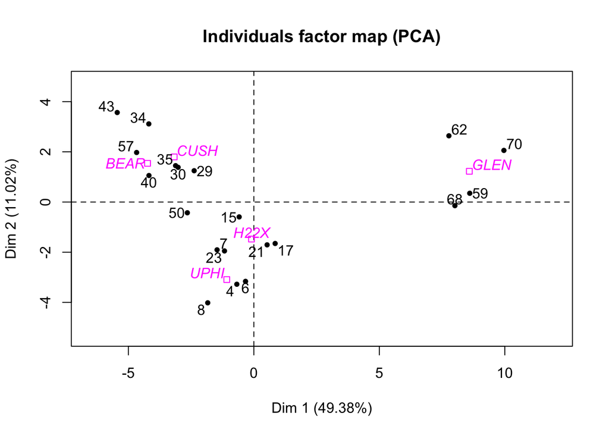

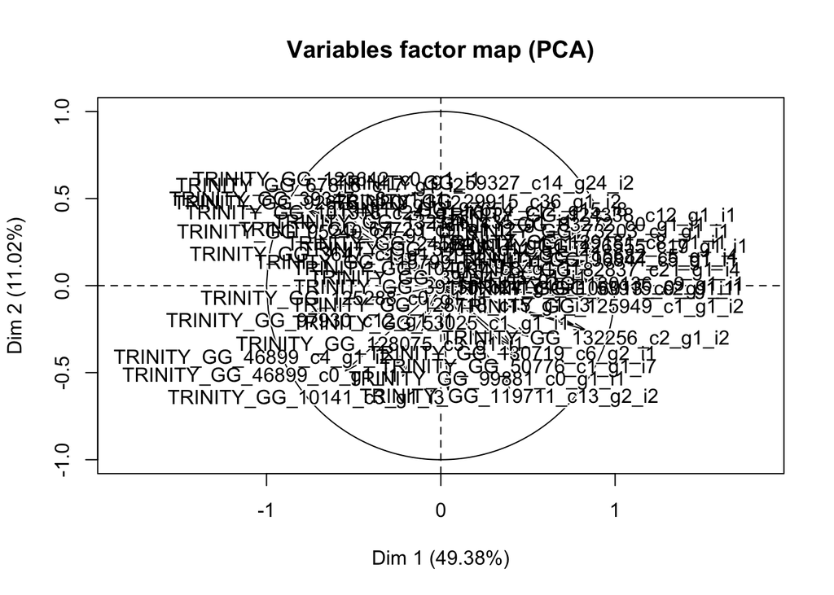

```r
### Run PCA on "PCAarray" Vector, stored as "res" vector
res = PCA(PCAarray, quali.sup = 1)
```

```r
### BE PATIENT!!! Wait until STOP sign disappears for 3 seconds (May Crash R)
### Should result in two maps: 1) Individuals factor map (GOOD) 2) Variables factor map (BAD)
```

### Step 11: Heatmap Visualization

### Use Sleuth Determined Differentially Expressed Genes (DEG)

```r
### Create & Set Working Directory
dir = "/Users/christopherjameshooey/Desktop/LAB INFO/Masters/MASTERS DATA/R FILES"
setwd(dir)

######### READ IN DATA #######################################################################
### Read in "Fulldata" that contains the differential expression data (FPKM/TPM) with gene IDs
Fulldata = read.table(paste(dir, "/Raw Data/Data Management", sep=""), header=T, dec=".", sep=",")

### Read in "Protein_names" for protein description information
Protein_names = read.table(paste(dir, "/Raw Data/Protein Names", sep=""), header=T, dec=".", sep=",")

### Read in Dataset "Chris-First-Full-Sleuth.csv" with Selected Genes to heatmap
Full_Sleuth = read.csv(("/Users/christopherjameshooey/Desktop/LAB INFO/Masters/MASTERS DATA/R FILES/Sleuth Analysis/Sleuth Complete (GENE & PROTEIN)-CSV Files/Chris-First-Full-Sleuth.csv"), header=T, dec=".", sep=",")

######### TRANSFORM DATA ##############################################################
### Create "selectedgenes" value composed from "Full_Sleuth" "target_id" column values
selectedgenes = Full_Sleuth$target_id

### Create "matrix" value composed of the target_id values from "Fulldata" that match "selectedgenes"
matrix = Fulldata[which(Fulldata$target_id %in% selectedgenes),]

### Add a Log transformation of FPKM values column to "matrix" named "logFPKM"
matrix$logFPKM = log(matrix$FPKM + 1)

### Transpose "matrix"
library(reshape2)

### Create a new column named "sampleID" that combines "Site" & "sample"
matrix$sampleID = paste(matrix$Site, matrix$sample, sep="_")

### Reshape "matrix" to include all rows but only the 4 named columns: "sampleID", "target_id", "gene_ID", "logFPKM"
matrix = matrix[, c("sampleID", "target_id", "gene_ID", "logFPKM")]

### Use function "dcast" to reshape "matrix" to have "target_id" & gene_ID as row names, "sampleID" as columns filled with "logFPKM" data values
matrix = dcast(matrix, target_id+gene_ID ~ sampleID, value.var="logFPKM")

### Use merge function to combine "matrix" & "Protein_names" by shared column "gene_ID" to gain protein functional information
matrix = merge(matrix, Protein_names[, c("gene_ID", "description")])

######### Simplify & Normalize "temp" to use as heatmap data ##################################
library(matrixStats)
citation("matrixStats")
```

```
##
##
##   Henrik Bengtsson (2016). matrixStats: Functions that Apply to
##   Rows and Columns of Matrices (and to Vectors). R package version
##   0.51.0. https://CRAN.R-project.org/package=matrixStats
##
## A BibTeX entry for LaTeX users is
##
##   @Manual{,
##     title = {matrixStats: Functions that Apply to Rows and Columns of Matrices (and to
## Vectors)},
##     author = {Henrik Bengtsson},
##     year = {2016},
##     note = {R package version 0.51.0},
##     url = {https://CRAN.R-project.org/package=matrixStats},
##   }
```

```r
### Create "temp" vector that removes the named columns
temp = matrix[,-which(names(matrix) %in% c("target_id", "gene_ID", "sampleID", "description"))]

### Convert "temp" to a matrix from data frame because of downstream restrictions
temp = as.matrix(temp)

### Perform Normalization Calculation on "temp" data
### (For one gene need min to max value -> zero-mean & unit-variance normalization)
temp = (temp-rowMeans(temp))/rowSds(temp)

######### Cluster info for heatmap ###########################################
### To cluster similar expression in "temp" data
### Creates a distance measure based on 1 minus the correlation of the transposed "temp" vector columns using the "pearson" correlation coefficient method
hr = hclust(as.dist(1-cor(t(temp), method = "pearson")), method = "complete")

### Create vector "nclass" to specify class number in case of change needed later
nclass = 2

### Adds the column mycl to "matrix"
### Using the "cutree" function "matrix" is cut by the specified number of classes (2) according to the "pearson" correlation coefficient relatedness
matrix$mycl = cutree(hr, k=nclass)

### Creates a new column in "matrix" named "rownum" to number the height/length of the rows
matrix$rownum = 1:nrow(matrix)

### Creates Value named "rowcol" based on the clustering above to visualize "mycl" as red & orange
rowcol = data.frame(mycl = c(1:2), rowcol = c("orange", "red"))

### Use the "merge" function to combine "matrix" & "rowcol" to add cluster data
matrix = merge(matrix, rowcol, sort = F)

### Rearranges "matrix" in accending order according to the "rownum" column data for all columns
matrix = matrix[order(matrix$rownum),]

######### Heatmap Specifications ##################################################

### Names the 3 colors to use on the heatmap to denote relative change (low to high)
colfunc = colorRampPalette(c("blue", "black", "yellow"))

### Gives each sample (20) number a specified color by site (5) group
colside = c("green", "green", "green", "green",
          "yellow", "yellow", "yellow", "yellow",
          "red", "red", "red", "red",
          "black", "black", "black", "black",
          "pink", "pink", "pink", "pink")

### Creates a vector "l" that is the length of the vector "temp" to make for easier heatmap adjustments
l = length(temp[,1])

library(gplots)
citation("gplots")
```

```
##
##
##   Gregory R. Warnes, Ben Bolker, Lodewijk Bonebakker, Robert
##   Gentleman, Wolfgang Huber Andy Liaw, Thomas Lumley, Martin
##   Maechler, Arni Magnusson, Steffen Moeller, Marc Schwartz and
##   Bill Venables (2016). gplots: Various R Programming Tools for
##   Plotting Data. R package version 3.0.1.
##   https://CRAN.R-project.org/package=gplots
##
## A BibTeX entry for LaTeX users is
##
##   @Manual{,
##     title = {gplots: Various R Programming Tools for Plotting Data},
##     author = {Gregory R. Warnes and Ben Bolker and Lodewijk Bonebakker and Robert Gentleman and Wolfgang Huber Andy Liaw and Thomas Lumley and Martin Maechler and Arni Magnusson and Steffen Moeller and Marc Schwartz and Bill Venables},
##     year = {2016},
##     note = {R package version 3.0.1},
##     url = {https://CRAN.R-project.org/package=gplots},
##   }
##
## ATTENTION: This citation information has been auto-generated from
## the package DESCRIPTION file and may need manual editing, see
## 'help("citation")'.
```

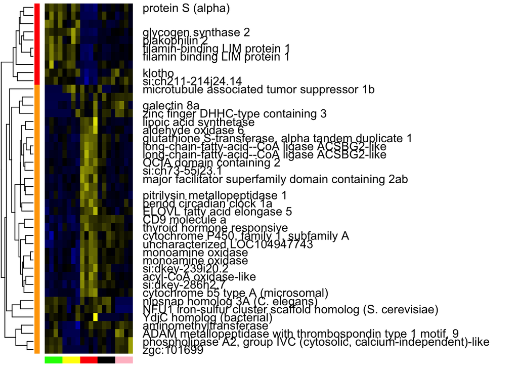

```r
### Generates a heatmap plot from "temp" data matrix to be stored as "heatmap-CHRIS HOOEY.tiff" in the set directory
### Numbers are to set dimension parameters are the result of trial & error & personal preference
plot.new()
par(mar=c(7,4,4,2)+0.1) # Set graphical parameters
out = heatmap.2(temp
              ,col = colfunc(200)
              ,Rowv = T
              ,Colv = F
              ,dendrogram = c("row") # Creates dendrogram connecting row data
              ,margins = c(0.3,13) # Determines margin sizes in cm units
              ,trace = "none"
              ,scale = "none"
              ,labRow = matrix$description # Creates row labels based on protein description
              ,labCol = ""
              ,density.info =c ("none")
              # RowsideColors, 1=Rowside colors, 2=heatmap, 3=rowdendo, 4=coldendo, 5=key
              ,lmat = rbind(c(0,0,5,0), c(4,1,3,0), c(0,0,2,0), c(0,0,6,0))   # RowsideColors & ColSideColors, 1=Rowside colors, 2=ColSideColors, 3=heatmap, 4=rowdendo, 5=coldendo, 6=key
              ,lwid = c(0.4,0.12,2.5,3) # Length of width
              ,lhei = c(0.1,l/4,l/120,0.05) # Length of height
              ,RowSideColors = as.character(matrix$rowcol) # Makes row colours red or orange
              ,ColSideColors = colside # Makes column colors equal to "colside" vector above
              ,key = F
              ,srtCol = 45
              ,cexRow = 1.45
)
```

References:

Bengtsson, H. (2016). matrixStats: Functions that Apply to Rows and Columns of Matrices (and to Vectors). R package version 0.51.0.https://CRAN.R-project.org/package=matrixStats

Lê, S., Josse, J. & Husson, F. (2008). FactoMineR: An R Package for Multivariate Analysis. Journal of Statistical Software. 25(1). pp. 1-18.

RStudio Team (2015). RStudio: Integrated Development for R. RStudio, Inc., Boston, MA URL http://www.rstudio.com/.

Warnes, G.R., Bolker, B., Bonebakker, L., Gentleman, R., Liaw, W.H.A., Lumley, T., Maechler, M., Magnusson, A., Moeller, S., Schwartz, M., & Venables, B. (2016). gplots: Various R Programming Tools for Plotting Data. R package version 3.0.1. https://CRAN.R-project.org/package=gplots

Wickham, H. (2007). Reshaping Data with the reshape Package. Journal of Statistical Software, 21(12), 1-20. URL http://www.jstatsoft.org/v21/i12/.